# Homework3

Guanlong

2018年2月28日

```r
library(ggplot2)

outFormat <- knitr::opts_knit$get("rmarkdown.pandoc.to")
```

## Q1 1)

$$Q(\Psi|\Psi^{(k)})= E_{z}\{l_{n}^{c}(\Psi\}\;=\sum_{i=1}^{n}\sum_{j=1}^{m}p_{ij}^{(k+1)}(z_{ij}|y_{i},x_{i};\Psi^{k})lnp(z_{i}=k,y_{i},x_{i}|\Psi)\;$$
$$where,p_{ij}^{(k+1)}(z_{ij}|y_{i},x_{i};\Psi^{k})=\frac{p(z_{i}=k,y_{i},x_{i}|\Psi^{k})}{\sum_{j=1}^{m}p(z_{j}=s,y_{i},x_{i}|\Psi^{k})}= \frac{\pi_{j}^{k}\phi(y_{i}-x_{i}^{T}\beta_{j}^{k};0,\sigma^{2})}{\sum_{j=1}^{m}\pi_{j}^{k}\phi(y_{i}-x_{i}^{T}\beta_{j}^{k};0,\sigma^{2})},\;and\;lnp(z_{i}=k,y_{i},x_{i}|\Psi)=log\pi_{j}+log\phi(y_{i}-x_{i}^{T}\beta_{j}^{k};0,\sigma^{2})$$
2.a)

the part of$Q(\Psi|\Psi^{(k)})$contains$pi_{j}^{k+1}$is$\sum_{i=1}^{n}\sum_{j=1}^{m}p_{ij}^{(k+1)}(z_{ij}|y_{i},x_{i};\Psi^{k})ln(2\pi)^{-d/2}\pi_{ij}^{k+1}$ and itis suffice to min
$$\sum_{i=1}^{n}(\sum_{j=1}^{m}p_{ij}^{(k+1)}(z_{ij}|y_{i},x_{i};\Psi^{k}))\pi_{ij}^{k+1}\;subject\;to\sum_{j=1}^{m}\pi_{ij}^{k+1}=1$$
then we get 2).a)

2b) the only part of$Q(\Psi|\Psi^{(k)})$contains$\beta_{j}^{k+1}$is
$$\sum_{i=1}^{n}p_{ij}^{(k+1)}(y_{i}-x_{i}^{T}\beta_{j})^{'}\Sigma_{k}^{-1}(y_{i}-x_{i}^{T}\beta_{j})$$
minimize it we find 2.b)

2.c) The only part of $Q(\Psi|\Psi^{(k)})$contains$\sigma^{2(k+1)}$is
$$\sum_{i=1}^{n}ln|\Sigma_{k}|+\sum_{i=1}^{n}p_{ij}^{(k+1)}(y_{i}-x_{i}^{T}\beta_{j})^{'}\Sigma_{k}^{-1}(y_{i}-x_{i}^{T}\beta_{j})$$
minimize this part we can get 2 c)

# Qestion 2

1. $$\int_{0}^{\infty}[2x^{\theta-1}e^{-x}+x^{\theta-\frac{1}{2}}e^{-x}]dx=\frac{1}{C},\;we\;have\;C=\frac{1}{2\Gamma(\theta)+\Gamma(\theta+\frac{1}{2})}$$
   and g is a mixture gamma with pdf:
   $$\frac{2\Gamma(\theta)}{2\Gamma(\theta)+\Gamma(\theta+\frac{1}{2})}\frac{1}{\Gamma(\theta)}x^{\theta-1}e^{-x}+\frac{\Gamma(\theta+\frac{1}{2})}{2\Gamma(\theta)+\Gamma(\theta+\frac{1}{2})}\frac{1}{\Gamma(\theta+\frac{1}{2})}x^{\theta+\frac{1}{2}-1}e^{-x}$$
   2b)

alg: first sample n integers from 1 and 2 acorrding to the probability$\frac{2\Gamma(\theta)}{2\Gamma(\theta)+\Gamma(\theta+\frac{1}{2})}$and the probability$\frac{\Gamma(\theta+\frac{1}{2})}{2\Gamma(\theta)+\Gamma(\theta+\frac{1}{2})}$, and then sample n observations from the 1th or 2nd gamma distribution acorrding to vector of sampled integer 1s and 2s

use density() to estimate the density from the sample and use real density function of g to calculate the true density from a generated x interval and then plot

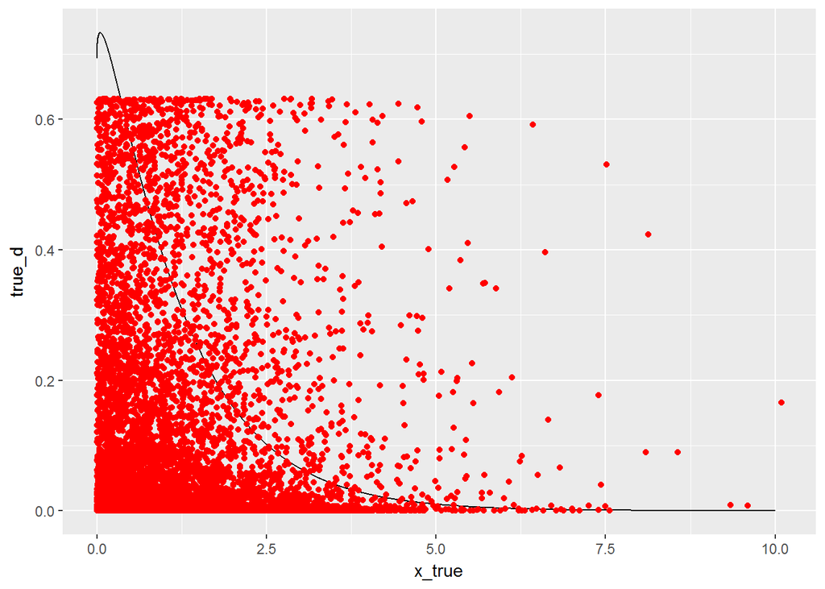

```r
# the true density function of g

mixgamma_d <- function (x,theta) {
g <- (2/(2*gamma(theta)+gamma(theta+0.5)))*x^(theta-1)*exp(-x)+(1/(2*gamma(theta)+gamma(theta+0.5)))*x^(theta-0.5)*exp(-x)

return(g)
}

# plot
sample_d <- density(x1, n=10000)$y  # density from the sample

x_true <- seq(from= 0, to = 9.999, by = (10/10000))      # intervel
true_d <- mixgamma_d(x_true,theta)
datafram1 <- data.frame(cbind(x_true,true_d))
datafram2 <- data.frame(cbind(x1,sample_d))
ggplot()+ geom_line(data=datafram1, aes(x=x_true, y=true_d))+
  geom_point(data=datafram2,aes(x=x1, sample_d), color='red')
```

2 c)

first step: # write a function to calculate the value of q(x)/g(x)

```r
# write a function to calculate the value of q(x)/g(x)

alfa <- function(x,theta) {

 alfa<- -(sqrt(4+x)*x^(theta-1)*exp(-x))/
  ((2/(2*gamma(theta)+gamma(theta+0.5)))*x^(theta-1)*exp(-x)+(1/(2*gamma(theta)+gamma(theta+0.5)))*x^(theta-0.5)*exp(-x))

 return(alfa)

}
```

second step: find the optimal value of alpha - the inverse of the accpetance rate

```r
a <- -nlminb(0.2,alfa, theta = 1)$objective
```

Third step: rejection sampling

```r
i <- 1
n2=1e4
x2 <- rep(0, n2)  # generate a empty vector of x2 for the final sample
while(i<= n2){

  u <- runif(1, min = 0, max = 1)      #initiate u
  x4 <- mixgamma(1, p, alpha, beta)    #initiate x4, which is a intermediate variable and changing within 'while' loop
  xr <- x4                             # initiate xr, if cond sati, we get xr without any loop
  while(u>(-1/a)*(alfa(x4,theta))) {     # comparing criteria to determin whether to continue drawing
    x4 <- mixgamma(1, p, alpha, beta)  # sampling new  x
    u <- runif(1, min = 0, max = 1)    # sampling new U
    xr <- x4                           # update xr, if this x4 satis condition, loop stops and we get xr, o.w. we get new x4 and xr
    }
   x2[i] =xr                     # you have to assign xr to x2[i] here, rather in the inner 'while'
i=i+1
}
```

plot

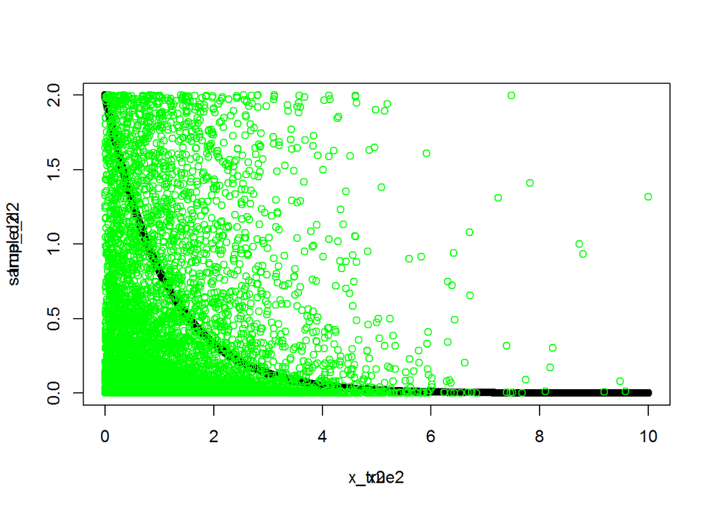

Q3

I used $\frac{1}{2}\beta(a,1)+\frac{1}{2}\beta(1,b)$ as the mixture beta to be the instrumental distribution

first write a function to sample from mixture of beta

```r
mixbeta <- function(x,n,a,b,lambda){


u2 <- runif(n, min = 0, max = 1)  # sample u2
v <- runif(n, min = 0, max = 1)   # sample v

    for (i in 1:length(u2)) {
      if (v[i]> lambda) {
        x[i]=u2[i]^(1/a)
     } else {
       x[i]=1-u2[i]^(1/b)
     }
    }
 return(x)
}


n3  <- 1e2
x3 <- rep(0,n3)
lambda <- 1/2
a <- 2
b <- 3

x_g<-mixbeta(x3,n3,a,b,lambda)
```

second write a function to calcualte q(x)/g(x) and a function to find value of alpha

```r
# write a function to calculate q(x)/g(x)

alpha2 <- function(x,a,b) {

return(  -(x^(a-1)/(1+x^2)+sqrt(2+x^2)*(1-x)^(b-1)) / ((1-lambda)*a*dbeta(x, a, 1)+lambda*b*dbeta(x,1, b))   )

}

-alpha2(0.5,2,3)
```

```
## [1] 0.3647059
```

```r
# calculate the value of alpha
a2 <- -nlminb(0.3,alpha2, a=2, b=3)$objective   #sensitive the the chose of lambda
```

Third to implement rejection sampling from f(x) with g(x) as the instrument function

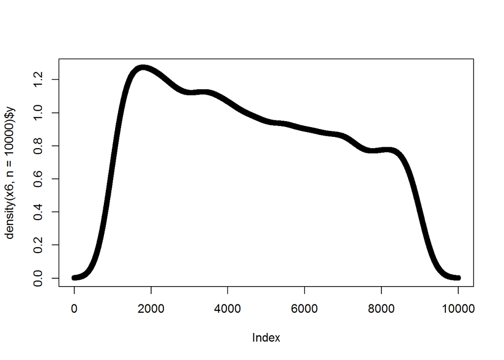

```r
i <- 1
n6=1e4            # length of final sample
x6 <- rep(0, n6)  # for the final sample from f(x)
x8 <- rep(0, 1)  # for the sample from g(x)
while(i<= n6){

  u <- runif(1, min = 0, max = 1)      #initiate u
  x7 <- mixbeta(x8, 1, a,b, lambda)    #initiate x4, which is a intermediate variable and changing within 'while' loop
  xr2 <- x7  # initiate xr2, if cond sati, we get xr2 without any loop
  while(u>(-1/a2)*alpha2(x7,a,b)) {     # comparing criteria to determin whether to continue drawing
    x7 <- mixbeta(x8, 1, a, b, lambda)  # sampling new  x
    u <- runif(1, min = 0, max = 1)    # sampling new U
    xr2 <- x7                          # update xr2 at the end of each loop, if cond sat, we get xr2 and loop stops
    }
  x6[i] =xr2                     # you have to assign xr to x2[i] here, rather in the inner 'while'
  i=i+1
}

plot(density(x6, n=10000)$y)
```

first write two functions calcualte g1(x) and g2(x), which are two beta distributions

```r
# generate a function calculate q1(x)/g1(x)

 ak1 <- function (x,a,b){
   return(  -(x^(a-1)/(1+x^2)) / a*dbeta(x, a, b)  )
 }

 # generate a function calculate q2(x)/g2(x)
 ak2 <- function (x,a,b){
   return(  -sqrt(2+x^2)*(1-x)^(b-1) / b*dbeta(x, a, b)    )
 }
```

Second # calculate the value of alpha1 and alpha2 and assign the value to p proportionally tp alpha1 &2

```r
 a1 <- c( 2, 1)  #specify parameter values
 b1 <- c( 1, 3)

 ak11 <- -nlminb(0.3,ak1, a=2,b=1)$objective
 ak22 <- -nlminb(0.3,ak2, a=1,b=3)$objective
 a6 <- c(ak11,ak22)
 p3 <- c( ak11/(ak11+ak22), ak22/(ak11+ak22))
```

Third rejection sampling: 1) generate a random integer k from k= 1,2 according to pk proportion to alphak 2) sample xk from gk and U 3) use goes back to step 1 if U>qk/gk, o.w.return xk and the first 100 of estimated density from the sample are showned

```r
 i <- 1
 n89=1e4
 x89 <- rep(0, n89)  # generate a empty vector of x2 for the final sample
 while(i<= n89){
   k3<- sample.int(length(p3), 1, replace= TRUE, prob = p3)  # initiate k3
   xgk <- rbeta(1, a1[k3],b1[k3])   # initiate xgk
   u6 <- runif(1, min = 0, max = 1) # initiate U
   xrr <- xgk  # initiate xrr, if cond sati, we get xrr before any loop
   # initiating: q(k)/g(k) using xk, for k =1 or 2
   if (k3==1) {
     qgk <- ak1(xgk,a1[1],b1[1])
   } else {
     qgk <- ak2(xgk,a1[2],b1[2])
   }
   while(u6>(-1/a6[k3])*qgk) { # to evaluate the condition use the vars from the last round
     k3<- sample.int(length(p3), 1, replace= TRUE, prob = p3) # sample one sample k from 1,2 with prob= p31, p32
     xgk <- rbeta(1, a1[k3],b1[k3])   # sample one xk from gk
     u6 <- runif(1, min = 0, max = 1)  # sample U
     xrr <- xgk  # update xrr, if cretia satisfied, loop stops, o.w. loop cont
     if (k3==1) {                     # calculate qk/gk whithin loop( actually part of the condition evaluation)
       qgk <- ak1(xgk,a1[1],b1[1])
     } else {
       qgk <- ak2(xgk,a1[2],b1[2])
     }

    }
   x89[i] =xrr                     # you have to assign xrr to x89[i] here, rather in the inner 'while'
   i=i+1

 }
 sample_d6 <- density(x89, n=10000)$y
 sample_d6[1:100]
```

```
##   [1] 0.005959153 0.006011508 0.006064293 0.006117480 0.006171074
##   [6] 0.006225133 0.006279619 0.006334520 0.006389840 0.006445650
##  [11] 0.006501887 0.006558550 0.006615655 0.006673255 0.006731292
##  [16] 0.006789767 0.006848711 0.006908149 0.006968036 0.007028375
##  [21] 0.007089209 0.007150537 0.007212327 0.007274580 0.007337357
##  [26] 0.007400629 0.007464373 0.007528595 0.007593370 0.007658638
##  [31] 0.007724392 0.007790644 0.007857466 0.007924785 0.007992604
##  [36] 0.008060950 0.008129867 0.008199294 0.008269235 0.008339734
##  [41] 0.008410802 0.008482395 0.008554515 0.008627226 0.008700505
##  [46] 0.008774322 0.008848681 0.008923665 0.008999213 0.009075315
##  [51] 0.009151976 0.009229292 0.009307172 0.009385620 0.009464661
##  [56] 0.009544355 0.009624629 0.009705487 0.009786971 0.009869109
##  [61] 0.009951841 0.010035172 0.010119166 0.010203811 0.010289066
##  [66] 0.010374936 0.010461507 0.010548725 0.010636571 0.010725047
##  [71] 0.010814263 0.010904123 0.010994627 0.011085794 0.011177708
##  [76] 0.011270279 0.011363511 0.011457444 0.011552123 0.011647476
##  [81] 0.011743505 0.011840277 0.011937793 0.012035999 0.012134900
##  [86] 0.012234585 0.012335009 0.012436143 0.012537988 0.012640662
##  [91] 0.012744071 0.012848206 0.012953082 0.013058811 0.013165280
##  [96] 0.013272494 0.013380492 0.013489340 0.013598947 0.013709319
```